# Risk Factor Analysis

## Outcome Variable

**Outcome Variable:** wast_rec90d

## Predictor Variables

**Intervention Variable:** impsan

**Adjustment Set:**

- arm
- sex
- W_mage
- meducyrs
- feducyrs
- hhwealth_quart
- hfoodsec
- W_mhtcm
- W_nrooms
- W_nchldlt5
- W_parity
- impfloor
- safeh20
- delta_W_mage
- delta_meducyrs
- delta_feducyrs
- delta_hhwealth_quart
- delta_hfoodsec
- delta_W_mhtcm
- delta_W_nrooms
- delta_W_nchldlt5
- delta_W_parity
- delta_impfloor
- delta_safeh20

## Stratifying Variables

The analysis was stratified on these variable(s):

- agecat
- studyid
- country

## Data Summary

| agecat | studyid | country | impsan | wast_rec90d | n_cell | n |
| --- | --- | --- | --- | --- | --- | --- |
| 0-24 months | ki0047075b-MAL-ED | BANGLADESH | 1 | 0 | 34 | 121 |
| 0-24 months | ki0047075b-MAL-ED | BANGLADESH | 1 | 1 | 66 | 121 |
| 0-24 months | ki0047075b-MAL-ED | BANGLADESH | 0 | 0 | 10 | 121 |
| 0-24 months | ki0047075b-MAL-ED | BANGLADESH | 0 | 1 | 11 | 121 |
| 0-24 months | ki0047075b-MAL-ED | BRAZIL | 1 | 0 | 6 | 23 |
| 0-24 months | ki0047075b-MAL-ED | BRAZIL | 1 | 1 | 16 | 23 |
| 0-24 months | ki0047075b-MAL-ED | BRAZIL | 0 | 0 | 0 | 23 |
| 0-24 months | ki0047075b-MAL-ED | BRAZIL | 0 | 1 | 1 | 23 |
| 0-24 months | ki0047075b-MAL-ED | INDIA | 1 | 0 | 25 | 170 |
| 0-24 months | ki0047075b-MAL-ED | INDIA | 1 | 1 | 41 | 170 |
| 0-24 months | ki0047075b-MAL-ED | INDIA | 0 | 0 | 40 | 170 |
| 0-24 months | ki0047075b-MAL-ED | INDIA | 0 | 1 | 64 | 170 |
| 0-24 months | ki0047075b-MAL-ED | NEPAL | 1 | 0 | 19 | 92 |
| 0-24 months | ki0047075b-MAL-ED | NEPAL | 1 | 1 | 73 | 92 |
| 0-24 months | ki0047075b-MAL-ED | NEPAL | 0 | 0 | 0 | 92 |
| 0-24 months | ki0047075b-MAL-ED | NEPAL | 0 | 1 | 0 | 92 |
| 0-24 months | ki0047075b-MAL-ED | PERU | 1 | 0 | 3 | 32 |
| 0-24 months | ki0047075b-MAL-ED | PERU | 1 | 1 | 6 | 32 |
| 0-24 months | ki0047075b-MAL-ED | PERU | 0 | 0 | 3 | 32 |
| 0-24 months | ki0047075b-MAL-ED | PERU | 0 | 1 | 20 | 32 |
| 0-24 months | ki0047075b-MAL-ED | SOUTH AFRICA | 1 | 0 | 1 | 76 |
| 0-24 months | ki0047075b-MAL-ED | SOUTH AFRICA | 1 | 1 | 1 | 76 |
| 0-24 months | ki0047075b-MAL-ED | SOUTH AFRICA | 0 | 0 | 11 | 76 |
| 0-24 months | ki0047075b-MAL-ED | SOUTH AFRICA | 0 | 1 | 63 | 76 |
| 0-24 months | ki0047075b-MAL-ED | TANZANIA, UNITED REPUBLIC OF | 1 | 0 | 0 | 44 |
| 0-24 months | ki0047075b-MAL-ED | TANZANIA, UNITED REPUBLIC OF | 1 | 1 | 0 | 44 |
| 0-24 months | ki0047075b-MAL-ED | TANZANIA, UNITED REPUBLIC OF | 0 | 0 | 8 | 44 |
| 0-24 months | ki0047075b-MAL-ED | TANZANIA, UNITED REPUBLIC OF | 0 | 1 | 36 | 44 |
| 0-24 months | ki1017093-NIH-Birth | BANGLADESH | 1 | 0 | 66 | 421 |
| 0-24 months | ki1017093-NIH-Birth | BANGLADESH | 1 | 1 | 81 | 421 |

[output cut: 174 more lines]

The following strata were considered:

- agecat: 0-24 months, studyid: ki0047075b-MAL-ED, country: BANGLADESH
- agecat: 0-24 months, studyid: ki0047075b-MAL-ED, country: BRAZIL
- agecat: 0-24 months, studyid: ki0047075b-MAL-ED, country: INDIA
- agecat: 0-24 months, studyid: ki0047075b-MAL-ED, country: NEPAL
- agecat: 0-24 months, studyid: ki0047075b-MAL-ED, country: PERU
- agecat: 0-24 months, studyid: ki0047075b-MAL-ED, country: SOUTH AFRICA
- agecat: 0-24 months, studyid: ki0047075b-MAL-ED, country: TANZANIA, UNITED REPUBLIC OF
- agecat: 0-24 months, studyid: ki1017093-NIH-Birth, country: BANGLADESH
- agecat: 0-24 months, studyid: ki1017093b-PROVIDE, country: BANGLADESH
- agecat: 0-24 months, studyid: ki1017093c-NIH-Crypto, country: BANGLADESH
- agecat: 0-24 months, studyid: ki1114097-CONTENT, country: PERU
- agecat: 0-24 months, studyid: ki1135781-COHORTS, country: GUATEMALA
- agecat: 0-24 months, studyid: ki1135781-COHORTS, country: INDIA
- agecat: 0-24 months, studyid: ki1135781-COHORTS, country: PHILIPPINES
- agecat: 0-24 months, studyid: ki1148112-LCNI-5, country: MALAWI
- agecat: 0-24 months, studyid: kiGH5241-JiVitA-3, country: BANGLADESH
- agecat: 0-24 months, studyid: kiGH5241-JiVitA-4, country: BANGLADESH
- agecat: 0-6 months, studyid: ki0047075b-MAL-ED, country: BANGLADESH
- agecat: 0-6 months, studyid: ki0047075b-MAL-ED, country: BRAZIL
- agecat: 0-6 months, studyid: ki0047075b-MAL-ED, country: INDIA
- agecat: 0-6 months, studyid: ki0047075b-MAL-ED, country: NEPAL
- agecat: 0-6 months, studyid: ki0047075b-MAL-ED, country: PERU
- agecat: 0-6 months, studyid: ki0047075b-MAL-ED, country: SOUTH AFRICA
- agecat: 0-6 months, studyid: ki0047075b-MAL-ED, country: TANZANIA, UNITED REPUBLIC OF
- agecat: 0-6 months, studyid: ki1017093-NIH-Birth, country: BANGLADESH
- agecat: 0-6 months, studyid: ki1017093b-PROVIDE, country: BANGLADESH
- agecat: 0-6 months, studyid: ki1017093c-NIH-Crypto, country: BANGLADESH
- agecat: 0-6 months, studyid: ki1114097-CONTENT, country: PERU
- agecat: 0-6 months, studyid: ki1135781-COHORTS, country: GUATEMALA
- agecat: 0-6 months, studyid: ki1135781-COHORTS, country: INDIA
- agecat: 0-6 months, studyid: ki1135781-COHORTS, country: PHILIPPINES
- agecat: 0-6 months, studyid: ki1148112-LCNI-5, country: MALAWI
- agecat: 0-6 months, studyid: kiGH5241-JiVitA-3, country: BANGLADESH
- agecat: 0-6 months, studyid: kiGH5241-JiVitA-4, country: BANGLADESH
- agecat: 6-24 months, studyid: ki0047075b-MAL-ED, country: BANGLADESH
- agecat: 6-24 months, studyid: ki0047075b-MAL-ED, country: BRAZIL
- agecat: 6-24 months, studyid: ki0047075b-MAL-ED, country: INDIA
- agecat: 6-24 months, studyid: ki0047075b-MAL-ED, country: NEPAL
- agecat: 6-24 months, studyid: ki0047075b-MAL-ED, country: PERU
- agecat: 6-24 months, studyid: ki0047075b-MAL-ED, country: SOUTH AFRICA
- agecat: 6-24 months, studyid: ki0047075b-MAL-ED, country: TANZANIA, UNITED REPUBLIC OF
- agecat: 6-24 months, studyid: ki1017093-NIH-Birth, country: BANGLADESH
- agecat: 6-24 months, studyid: ki1017093b-PROVIDE, country: BANGLADESH
- agecat: 6-24 months, studyid: ki1017093c-NIH-Crypto, country: BANGLADESH
- agecat: 6-24 months, studyid: ki1114097-CONTENT, country: PERU
- agecat: 6-24 months, studyid: ki1135781-COHORTS, country: GUATEMALA
- agecat: 6-24 months, studyid: ki1135781-COHORTS, country: INDIA
- agecat: 6-24 months, studyid: ki1135781-COHORTS, country: PHILIPPINES
- agecat: 6-24 months, studyid: ki1148112-LCNI-5, country: MALAWI
- agecat: 6-24 months, studyid: kiGH5241-JiVitA-3, country: BANGLADESH
- agecat: 6-24 months, studyid: kiGH5241-JiVitA-4, country: BANGLADESH

### Dropped Strata

Some strata were dropped due to rare outcomes:

- agecat: 0-24 months, studyid: ki0047075b-MAL-ED, country: BRAZIL
- agecat: 0-24 months, studyid: ki0047075b-MAL-ED, country: NEPAL
- agecat: 0-24 months, studyid: ki0047075b-MAL-ED, country: PERU
- agecat: 0-24 months, studyid: ki0047075b-MAL-ED, country: SOUTH AFRICA
- agecat: 0-24 months, studyid: ki0047075b-MAL-ED, country: TANZANIA, UNITED REPUBLIC OF
- agecat: 0-24 months, studyid: ki1114097-CONTENT, country: PERU
- agecat: 0-24 months, studyid: ki1148112-LCNI-5, country: MALAWI
- agecat: 0-6 months, studyid: ki0047075b-MAL-ED, country: BANGLADESH
- agecat: 0-6 months, studyid: ki0047075b-MAL-ED, country: BRAZIL
- agecat: 0-6 months, studyid: ki0047075b-MAL-ED, country: NEPAL
- agecat: 0-6 months, studyid: ki0047075b-MAL-ED, country: PERU
- agecat: 0-6 months, studyid: ki0047075b-MAL-ED, country: SOUTH AFRICA
- agecat: 0-6 months, studyid: ki0047075b-MAL-ED, country: TANZANIA, UNITED REPUBLIC OF
- agecat: 0-6 months, studyid: ki1017093b-PROVIDE, country: BANGLADESH
- agecat: 0-6 months, studyid: ki1017093c-NIH-Crypto, country: BANGLADESH
- agecat: 0-6 months, studyid: ki1114097-CONTENT, country: PERU
- agecat: 0-6 months, studyid: ki1135781-COHORTS, country: GUATEMALA
- agecat: 0-6 months, studyid: ki1148112-LCNI-5, country: MALAWI
- agecat: 6-24 months, studyid: ki0047075b-MAL-ED, country: BANGLADESH
- agecat: 6-24 months, studyid: ki0047075b-MAL-ED, country: BRAZIL
- agecat: 6-24 months, studyid: ki0047075b-MAL-ED, country: NEPAL
- agecat: 6-24 months, studyid: ki0047075b-MAL-ED, country: PERU
- agecat: 6-24 months, studyid: ki0047075b-MAL-ED, country: SOUTH AFRICA
- agecat: 6-24 months, studyid: ki0047075b-MAL-ED, country: TANZANIA, UNITED REPUBLIC OF
- agecat: 6-24 months, studyid: ki1017093b-PROVIDE, country: BANGLADESH
- agecat: 6-24 months, studyid: ki1017093c-NIH-Crypto, country: BANGLADESH
- agecat: 6-24 months, studyid: ki1114097-CONTENT, country: PERU
- agecat: 6-24 months, studyid: ki1135781-COHORTS, country: GUATEMALA
- agecat: 6-24 months, studyid: ki1135781-COHORTS, country: INDIA
- agecat: 6-24 months, studyid: ki1148112-LCNI-5, country: MALAWI
- agecat: 6-24 months, studyid: kiGH5241-JiVitA-3, country: BANGLADESH

## Methods Detail

We’re interested in the causal parameters $E[Y_a]$ for all values of $a \in \mathcal{A}$. These parameters represent the mean outcome if, possibly contrary to fact, we intervened to set all units to have $A=a$. Under the randomization and positivity assumptions, these are identified by the statistical parameters $\psi_a=E_W[E_{Y|A,W}(Y|A=a,W)]$. In addition, we’re interested in the mean of $Y$, $E[Y]$ under no intervention (the observed mean). We will estimate these parameters by using SuperLearner to fit the relevant likelihood factors – $E_{Y|A,W}(Y|A=a,W)$ and $p(A=a|W)$, and then updating our likelihood fit using a joint TMLE.

For unadjusted analyses ($W=\{\}$), initial likelihoods were estimated using Lrnr_glm to estimate the simple $E(Y|A)$ and Lrnr_mean to estimate $p(A)$. For adjusted analyses, a small library containing Lrnr_glmnet, Lrnr_xgboost, and Lrnr_mean was used.

Having estimated these parameters, we will then use the delta method to estimate relative risks and attributable risks relative to a prespecified baseline level of $A$.

# Results Detail

## Results Plots

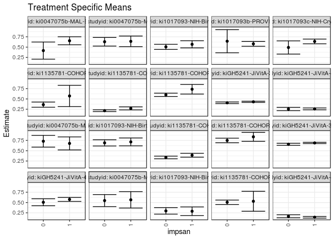

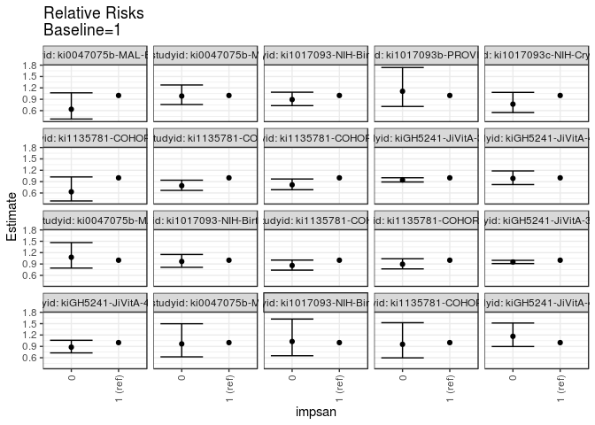

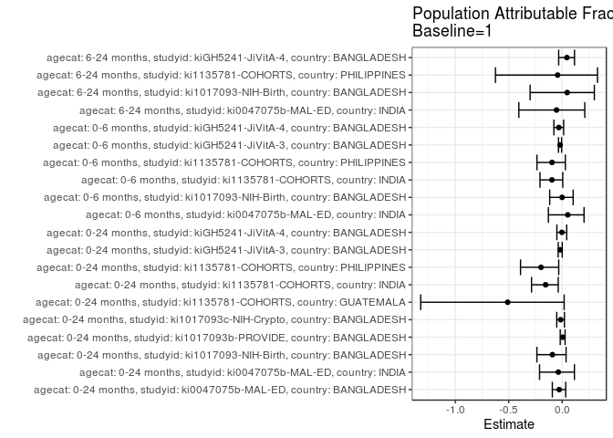

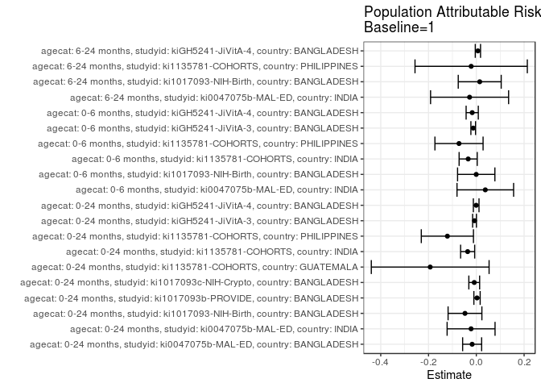

## Results Table

### Parameter: TSM

| agecat | studyid | country | intervention_level | baseline_level | estimate | ci_lower | ci_upper |
| --- | --- | --- | --- | --- | --- | --- | --- |
| 0-24 months | ki0047075b-MAL-ED | BANGLADESH | 1 | NA | 0.6538596 | 0.5569211 | 0.7507980 |
| 0-24 months | ki0047075b-MAL-ED | BANGLADESH | 0 | NA | 0.4159115 | 0.2086905 | 0.6231326 |
| 0-24 months | ki0047075b-MAL-ED | INDIA | 1 | NA | 0.6395556 | 0.5108581 | 0.7682531 |
| 0-24 months | ki0047075b-MAL-ED | INDIA | 0 | NA | 0.6297805 | 0.5252678 | 0.7342931 |
| 0-24 months | ki1017093-NIH-Birth | BANGLADESH | 1 | NA | 0.5676109 | 0.4801744 | 0.6550473 |
| 0-24 months | ki1017093-NIH-Birth | BANGLADESH | 0 | NA | 0.5062630 | 0.4441035 | 0.5684225 |
| 0-24 months | ki1017093b-PROVIDE | BANGLADESH | 1 | NA | 0.5787671 | 0.5206376 | 0.6368967 |
| 0-24 months | ki1017093b-PROVIDE | BANGLADESH | 0 | NA | 0.6428571 | 0.3621822 | 0.9235321 |
| 0-24 months | ki1017093c-NIH-Crypto | BANGLADESH | 1 | NA | 0.6373657 | 0.5800620 | 0.6946693 |
| 0-24 months | ki1017093c-NIH-Crypto | BANGLADESH | 0 | NA | 0.4912697 | 0.3312343 | 0.6513051 |
| 0-24 months | ki1135781-COHORTS | GUATEMALA | 1 | NA | 0.5717998 | 0.3142272 | 0.8293723 |
| 0-24 months | ki1135781-COHORTS | GUATEMALA | 0 | NA | 0.3612583 | 0.2983442 | 0.4241724 |
| 0-24 months | ki1135781-COHORTS | INDIA | 1 | NA | 0.2707370 | 0.2339860 | 0.3074879 |
| 0-24 months | ki1135781-COHORTS | INDIA | 0 | NA | 0.2144910 | 0.1927747 | 0.2362073 |
| 0-24 months | ki1135781-COHORTS | PHILIPPINES | 1 | NA | 0.7345829 | 0.6180939 | 0.8510720 |
| 0-24 months | ki1135781-COHORTS | PHILIPPINES | 0 | NA | 0.5992807 | 0.5588398 | 0.6397217 |
| 0-24 months | kiGH5241-JiVitA-3 | BANGLADESH | 1 | NA | 0.4301559 | 0.4162556 | 0.4440562 |
| 0-24 months | kiGH5241-JiVitA-3 | BANGLADESH | 0 | NA | 0.4063174 | 0.3861180 | 0.4265168 |
| 0-24 months | kiGH5241-JiVitA-4 | BANGLADESH | 1 | NA | 0.2585879 | 0.2355763 | 0.2815995 |
| 0-24 months | kiGH5241-JiVitA-4 | BANGLADESH | 0 | NA | 0.2550076 | 0.2146442 | 0.2953709 |
| 0-6 months | ki0047075b-MAL-ED | INDIA | 1 | NA | 0.6766627 | 0.5188771 | 0.8344482 |
| 0-6 months | ki0047075b-MAL-ED | INDIA | 0 | NA | 0.7294837 | 0.5871401 | 0.8718273 |
| 0-6 months | ki1017093-NIH-Birth | BANGLADESH | 1 | NA | 0.7133962 | 0.6181825 | 0.8086099 |
| 0-6 months | ki1017093-NIH-Birth | BANGLADESH | 0 | NA | 0.6900991 | 0.6143853 | 0.7658130 |
| 0-6 months | ki1135781-COHORTS | INDIA | 1 | NA | 0.3906793 | 0.3441340 | 0.4372246 |
| 0-6 months | ki1135781-COHORTS | INDIA | 0 | NA | 0.3365364 | 0.3041296 | 0.3689432 |
| 0-6 months | ki1135781-COHORTS | PHILIPPINES | 1 | NA | 0.8367347 | 0.7280039 | 0.9454655 |
| 0-6 months | ki1135781-COHORTS | PHILIPPINES | 0 | NA | 0.7489177 | 0.6935154 | 0.8043201 |
| 0-6 months | kiGH5241-JiVitA-3 | BANGLADESH | 1 | NA | 0.6885849 | 0.6722725 | 0.7048973 |
| 0-6 months | kiGH5241-JiVitA-3 | BANGLADESH | 0 | NA | 0.6563625 | 0.6313581 | 0.6813669 |
| 0-6 months | kiGH5241-JiVitA-4 | BANGLADESH | 1 | NA | 0.5755866 | 0.5271109 | 0.6240624 |
| 0-6 months | kiGH5241-JiVitA-4 | BANGLADESH | 0 | NA | 0.5060064 | 0.4210875 | 0.5909253 |
| 6-24 months | ki0047075b-MAL-ED | INDIA | 1 | NA | 0.5658074 | 0.3671275 | 0.7644873 |
| 6-24 months | ki0047075b-MAL-ED | INDIA | 0 | NA | 0.5467205 | 0.4007298 | 0.6927112 |
| 6-24 months | ki1017093-NIH-Birth | BANGLADESH | 1 | NA | 0.2887544 | 0.1839847 | 0.3935241 |
| 6-24 months | ki1017093-NIH-Birth | BANGLADESH | 0 | NA | 0.2972585 | 0.2185249 | 0.3759921 |
| 6-24 months | ki1135781-COHORTS | PHILIPPINES | 1 | NA | 0.5302591 | 0.2884079 | 0.7721104 |
| 6-24 months | ki1135781-COHORTS | PHILIPPINES | 0 | NA | 0.5061532 | 0.4521714 | 0.5601351 |
| 6-24 months | kiGH5241-JiVitA-4 | BANGLADESH | 1 | NA | 0.1426357 | 0.1219600 | 0.1633115 |
| 6-24 months | kiGH5241-JiVitA-4 | BANGLADESH | 0 | NA | 0.1663411 | 0.1299156 | 0.2027666 |

### Parameter: E(Y)

| agecat | studyid | country | intervention_level | baseline_level | estimate | ci_lower | ci_upper |
| --- | --- | --- | --- | --- | --- | --- | --- |
| 0-24 months | ki0047075b-MAL-ED | BANGLADESH | NA | NA | 0.6363636 | 0.5494154 | 0.7233119 |
| 0-24 months | ki0047075b-MAL-ED | INDIA | NA | NA | 0.6176471 | 0.5365376 | 0.6987565 |
| 0-24 months | ki1017093-NIH-Birth | BANGLADESH | NA | NA | 0.5201900 | 0.4695846 | 0.5707955 |
| 0-24 months | ki1017093b-PROVIDE | BANGLADESH | NA | NA | 0.5816993 | 0.5247676 | 0.6386311 |
| 0-24 months | ki1017093c-NIH-Crypto | BANGLADESH | NA | NA | 0.6286645 | 0.5746609 | 0.6826681 |
| 0-24 months | ki1135781-COHORTS | GUATEMALA | NA | NA | 0.3787879 | 0.3179432 | 0.4396325 |
| 0-24 months | ki1135781-COHORTS | INDIA | NA | NA | 0.2344546 | 0.2156201 | 0.2532892 |
| 0-24 months | ki1135781-COHORTS | PHILIPPINES | NA | NA | 0.6134700 | 0.5751620 | 0.6517779 |
| 0-24 months | kiGH5241-JiVitA-3 | BANGLADESH | NA | NA | 0.4226600 | 0.4115317 | 0.4337883 |
| 0-24 months | kiGH5241-JiVitA-4 | BANGLADESH | NA | NA | 0.2580019 | 0.2386523 | 0.2773515 |
| 0-6 months | ki0047075b-MAL-ED | INDIA | NA | NA | 0.7142857 | 0.6098683 | 0.8187031 |
| 0-6 months | ki1017093-NIH-Birth | BANGLADESH | NA | NA | 0.7130045 | 0.6535890 | 0.7724200 |
| 0-6 months | ki1135781-COHORTS | INDIA | NA | NA | 0.3565891 | 0.3304405 | 0.3827378 |
| 0-6 months | ki1135781-COHORTS | PHILIPPINES | NA | NA | 0.7642857 | 0.7146210 | 0.8139505 |
| 0-6 months | kiGH5241-JiVitA-3 | BANGLADESH | NA | NA | 0.6756128 | 0.6622741 | 0.6889516 |
| 0-6 months | kiGH5241-JiVitA-4 | BANGLADESH | NA | NA | 0.5583942 | 0.5167799 | 0.6000084 |
| 6-24 months | ki0047075b-MAL-ED | INDIA | NA | NA | 0.5376344 | 0.4216441 | 0.6536248 |
| 6-24 months | ki1017093-NIH-Birth | BANGLADESH | NA | NA | 0.3030303 | 0.2377927 | 0.3682679 |
| 6-24 months | ki1135781-COHORTS | PHILIPPINES | NA | NA | 0.5086849 | 0.4571562 | 0.5602135 |
| 6-24 months | kiGH5241-JiVitA-4 | BANGLADESH | NA | NA | 0.1492734 | 0.1316631 | 0.1668838 |

### Parameter: RR

| agecat | studyid | country | intervention_level | baseline_level | estimate | ci_lower | ci_upper |
| --- | --- | --- | --- | --- | --- | --- | --- |
| 0-24 months | ki0047075b-MAL-ED | BANGLADESH | 1 | 1 | 1.0000000 | 1.0000000 | 1.0000000 |
| 0-24 months | ki0047075b-MAL-ED | BANGLADESH | 0 | 1 | 0.6360870 | 0.3780367 | 1.0702841 |
| 0-24 months | ki0047075b-MAL-ED | INDIA | 1 | 1 | 1.0000000 | 1.0000000 | 1.0000000 |
| 0-24 months | ki0047075b-MAL-ED | INDIA | 0 | 1 | 0.9847157 | 0.7595213 | 1.2766792 |
| 0-24 months | ki1017093-NIH-Birth | BANGLADESH | 1 | 1 | 1.0000000 | 1.0000000 | 1.0000000 |
| 0-24 months | ki1017093-NIH-Birth | BANGLADESH | 0 | 1 | 0.8919192 | 0.7320315 | 1.0867291 |
| 0-24 months | ki1017093b-PROVIDE | BANGLADESH | 1 | 1 | 1.0000000 | 1.0000000 | 1.0000000 |
| 0-24 months | ki1017093b-PROVIDE | BANGLADESH | 0 | 1 | 1.1107354 | 0.7096843 | 1.7384254 |
| 0-24 months | ki1017093c-NIH-Crypto | BANGLADESH | 1 | 1 | 1.0000000 | 1.0000000 | 1.0000000 |
| 0-24 months | ki1017093c-NIH-Crypto | BANGLADESH | 0 | 1 | 0.7707816 | 0.5489430 | 1.0822695 |
| 0-24 months | ki1135781-COHORTS | GUATEMALA | 1 | 1 | 1.0000000 | 1.0000000 | 1.0000000 |
| 0-24 months | ki1135781-COHORTS | GUATEMALA | 0 | 1 | 0.6317916 | 0.3899597 | 1.0235945 |
| 0-24 months | ki1135781-COHORTS | INDIA | 1 | 1 | 1.0000000 | 1.0000000 | 1.0000000 |
| 0-24 months | ki1135781-COHORTS | INDIA | 0 | 1 | 0.7922487 | 0.6689414 | 0.9382855 |
| 0-24 months | ki1135781-COHORTS | PHILIPPINES | 1 | 1 | 1.0000000 | 1.0000000 | 1.0000000 |
| 0-24 months | ki1135781-COHORTS | PHILIPPINES | 0 | 1 | 0.8158109 | 0.6865952 | 0.9693446 |
| 0-24 months | kiGH5241-JiVitA-3 | BANGLADESH | 1 | 1 | 1.0000000 | 1.0000000 | 1.0000000 |
| 0-24 months | kiGH5241-JiVitA-3 | BANGLADESH | 0 | 1 | 0.9445817 | 0.8905969 | 1.0018387 |
| 0-24 months | kiGH5241-JiVitA-4 | BANGLADESH | 1 | 1 | 1.0000000 | 1.0000000 | 1.0000000 |
| 0-24 months | kiGH5241-JiVitA-4 | BANGLADESH | 0 | 1 | 0.9861543 | 0.8223530 | 1.1825827 |
| 0-6 months | ki0047075b-MAL-ED | INDIA | 1 | 1 | 1.0000000 | 1.0000000 | 1.0000000 |
| 0-6 months | ki0047075b-MAL-ED | INDIA | 0 | 1 | 1.0780611 | 0.7926717 | 1.4662006 |
| 0-6 months | ki1017093-NIH-Birth | BANGLADESH | 1 | 1 | 1.0000000 | 1.0000000 | 1.0000000 |
| 0-6 months | ki1017093-NIH-Birth | BANGLADESH | 0 | 1 | 0.9673435 | 0.8125900 | 1.1515689 |
| 0-6 months | ki1135781-COHORTS | INDIA | 1 | 1 | 1.0000000 | 1.0000000 | 1.0000000 |
| 0-6 months | ki1135781-COHORTS | INDIA | 0 | 1 | 0.8614134 | 0.7391429 | 1.0039101 |
| 0-6 months | ki1135781-COHORTS | PHILIPPINES | 1 | 1 | 1.0000000 | 1.0000000 | 1.0000000 |
| 0-6 months | ki1135781-COHORTS | PHILIPPINES | 0 | 1 | 0.8950480 | 0.7707387 | 1.0394068 |
| 0-6 months | kiGH5241-JiVitA-3 | BANGLADESH | 1 | 1 | 1.0000000 | 1.0000000 | 1.0000000 |
| 0-6 months | kiGH5241-JiVitA-3 | BANGLADESH | 0 | 1 | 0.9532049 | 0.9117375 | 0.9965583 |
| 0-6 months | kiGH5241-JiVitA-4 | BANGLADESH | 1 | 1 | 1.0000000 | 1.0000000 | 1.0000000 |
| 0-6 months | kiGH5241-JiVitA-4 | BANGLADESH | 0 | 1 | 0.8791142 | 0.7284692 | 1.0609122 |
| 6-24 months | ki0047075b-MAL-ED | INDIA | 1 | 1 | 1.0000000 | 1.0000000 | 1.0000000 |
| 6-24 months | ki0047075b-MAL-ED | INDIA | 0 | 1 | 0.9662661 | 0.6234936 | 1.4974814 |
| 6-24 months | ki1017093-NIH-Birth | BANGLADESH | 1 | 1 | 1.0000000 | 1.0000000 | 1.0000000 |
| 6-24 months | ki1017093-NIH-Birth | BANGLADESH | 0 | 1 | 1.0294510 | 0.6536321 | 1.6213545 |
| 6-24 months | ki1135781-COHORTS | PHILIPPINES | 1 | 1 | 1.0000000 | 1.0000000 | 1.0000000 |
| 6-24 months | ki1135781-COHORTS | PHILIPPINES | 0 | 1 | 0.9545394 | 0.5975079 | 1.5249096 |
| 6-24 months | kiGH5241-JiVitA-4 | BANGLADESH | 1 | 1 | 1.0000000 | 1.0000000 | 1.0000000 |
| 6-24 months | kiGH5241-JiVitA-4 | BANGLADESH | 0 | 1 | 1.1661950 | 0.8967275 | 1.5166378 |

### Parameter: PAR

| agecat | studyid | country | intervention_level | baseline_level | estimate | ci_lower | ci_upper |
| --- | --- | --- | --- | --- | --- | --- | --- |
| 0-24 months | ki0047075b-MAL-ED | BANGLADESH | 1 | NA | -0.0174959 | -0.0572533 | 0.0222615 |
| 0-24 months | ki0047075b-MAL-ED | INDIA | 1 | NA | -0.0219086 | -0.1222023 | 0.0783851 |
| 0-24 months | ki1017093-NIH-Birth | BANGLADESH | 1 | NA | -0.0474208 | -0.1181311 | 0.0232894 |
| 0-24 months | ki1017093b-PROVIDE | BANGLADESH | 1 | NA | 0.0029322 | -0.0102359 | 0.0161003 |
| 0-24 months | ki1017093c-NIH-Crypto | BANGLADESH | 1 | NA | -0.0087012 | -0.0312763 | 0.0138739 |
| 0-24 months | ki1135781-COHORTS | GUATEMALA | 1 | NA | -0.1930119 | -0.4394813 | 0.0534575 |
| 0-24 months | ki1135781-COHORTS | INDIA | 1 | NA | -0.0362823 | -0.0657085 | -0.0068562 |
| 0-24 months | ki1135781-COHORTS | PHILIPPINES | 1 | NA | -0.1211129 | -0.2302606 | -0.0119653 |
| 0-24 months | kiGH5241-JiVitA-3 | BANGLADESH | 1 | NA | -0.0074960 | -0.0154477 | 0.0004558 |
| 0-24 months | kiGH5241-JiVitA-4 | BANGLADESH | 1 | NA | -0.0005859 | -0.0124157 | 0.0112438 |
| 0-6 months | ki0047075b-MAL-ED | INDIA | 1 | NA | 0.0376231 | -0.0808383 | 0.1560844 |
| 0-6 months | ki1017093-NIH-Birth | BANGLADESH | 1 | NA | -0.0003917 | -0.0784714 | 0.0776879 |
| 0-6 months | ki1135781-COHORTS | INDIA | 1 | NA | -0.0340902 | -0.0719715 | 0.0037912 |
| 0-6 months | ki1135781-COHORTS | PHILIPPINES | 1 | NA | -0.0724490 | -0.1732018 | 0.0283039 |
| 0-6 months | kiGH5241-JiVitA-3 | BANGLADESH | 1 | NA | -0.0129721 | -0.0227127 | -0.0032314 |
| 0-6 months | kiGH5241-JiVitA-4 | BANGLADESH | 1 | NA | -0.0171925 | -0.0426786 | 0.0082937 |
| 6-24 months | ki0047075b-MAL-ED | INDIA | 1 | NA | -0.0281730 | -0.1914628 | 0.1351168 |
| 6-24 months | ki1017093-NIH-Birth | BANGLADESH | 1 | NA | 0.0142759 | -0.0756280 | 0.1041798 |
| 6-24 months | ki1135781-COHORTS | PHILIPPINES | 1 | NA | -0.0215743 | -0.2566010 | 0.2134525 |
| 6-24 months | kiGH5241-JiVitA-4 | BANGLADESH | 1 | NA | 0.0066377 | -0.0043647 | 0.0176401 |

### Parameter: PAF

| agecat | studyid | country | intervention_level | baseline_level | estimate | ci_lower | ci_upper |
| --- | --- | --- | --- | --- | --- | --- | --- |
| 0-24 months | ki0047075b-MAL-ED | BANGLADESH | 1 | NA | -0.0274936 | -0.0918800 | 0.0330960 |
| 0-24 months | ki0047075b-MAL-ED | INDIA | 1 | NA | -0.0354710 | -0.2113789 | 0.1148928 |
| 0-24 months | ki1017093-NIH-Birth | BANGLADESH | 1 | NA | -0.0911606 | -0.2361310 | 0.0368081 |
| 0-24 months | ki1017093b-PROVIDE | BANGLADESH | 1 | NA | 0.0050408 | -0.0178496 | 0.0274163 |
| 0-24 months | ki1017093c-NIH-Crypto | BANGLADESH | 1 | NA | -0.0138407 | -0.0504860 | 0.0215263 |
| 0-24 months | ki1135781-COHORTS | GUATEMALA | 1 | NA | -0.5095513 | -1.3229536 | 0.0190311 |
| 0-24 months | ki1135781-COHORTS | INDIA | 1 | NA | -0.1547520 | -0.2863939 | -0.0365815 |
| 0-24 months | ki1135781-COHORTS | PHILIPPINES | 1 | NA | -0.1974228 | -0.3894111 | -0.0319634 |
| 0-24 months | kiGH5241-JiVitA-3 | BANGLADESH | 1 | NA | -0.0177352 | -0.0367132 | 0.0008953 |
| 0-24 months | kiGH5241-JiVitA-4 | BANGLADESH | 1 | NA | -0.0022711 | -0.0491817 | 0.0425420 |
| 0-6 months | ki0047075b-MAL-ED | INDIA | 1 | NA | 0.0526723 | -0.1287743 | 0.2049520 |
| 0-6 months | ki1017093-NIH-Birth | BANGLADESH | 1 | NA | -0.0005494 | -0.1162779 | 0.1031811 |
| 0-6 months | ki1135781-COHORTS | INDIA | 1 | NA | -0.0956006 | -0.2072227 | 0.0057006 |
| 0-6 months | ki1135781-COHORTS | PHILIPPINES | 1 | NA | -0.0947931 | -0.2355973 | 0.0299657 |
| 0-6 months | kiGH5241-JiVitA-3 | BANGLADESH | 1 | NA | -0.0192004 | -0.0337353 | -0.0048699 |
| 0-6 months | kiGH5241-JiVitA-4 | BANGLADESH | 1 | NA | -0.0307892 | -0.0775523 | 0.0139446 |
| 6-24 months | ki0047075b-MAL-ED | INDIA | 1 | NA | -0.0524018 | -0.4050225 | 0.2117212 |
| 6-24 months | ki1017093-NIH-Birth | BANGLADESH | 1 | NA | 0.0471105 | -0.2995771 | 0.3013124 |
| 6-24 months | ki1135781-COHORTS | PHILIPPINES | 1 | NA | -0.0424119 | -0.6236624 | 0.3307583 |
| 6-24 months | kiGH5241-JiVitA-4 | BANGLADESH | 1 | NA | 0.0444667 | -0.0323046 | 0.1155287 |